# Data Science Pipeline Tutorial

Lucas Balangero

CMSC320 Final Project Tutorial

5/17/2021

## Introduction

In This tutorial, I will be showing how to do a data science analysis on motorcycle accidents compared to car accidents using Python. I have recently decided to start riding a motorcycle and wanted to know how much more dangerous motorcycles are compared to car.

## Set Up

```python
import pandas as pd
import matplotlib.pyplot as plt
import numpy as np
import seaborn as sns
from sklearn import linear_model
from sklearn.preprocessing import RobustScaler
from sklearn.model_selection import train_test_split

%matplotlib inline
plt.rcParams["figure.figsize"] = [15, 10]
```

## Data Loading

I will be loading a data from https://opendata.maryland.gov/ which is an open source website from the U.S. Government. Since I will be riding mostly in Maryland, thats where I will like to focus on. The 1.24 million events recorded are from 2015 to 2020. The exact link for this database is https://opendata.maryland.gov/Public-Safety/Maryland-Statewide-Vehicle-Crashes-Vehicle-Details/mhft-5t5y

```python
#Data from 2015-2020
data = pd.read_csv("Maryland_Statewide_Vehicle_Crashes_-_Vehicle_Details.tsv", sep='\t')
data.head()
```

|  | HARM_EVENT_DESC | HARM_EVENT_CODE | CONTI_DIRECTION_DESC | CONTI_DIRECTION_CODE | DAMAGE_DESC | DAMAGE_CODE | MOVEMENT_DESC | MOVEMENT_CODE | VIN_NO | REPORT_NO | ... | TOWED_VEHICLE_CONFIG_DESC | TOWED_VEHICLE_CONFIG_CODE | AREA_DAMAGED_CODE_IMP1 | AREA_DAMAGED_CODE1 | AREA_DAMAGED_CODE2 | AREA_DAMAGED_CODE3 | AREA_DAMAGED_CODE_MAIN_DESC | AREA_DAMAGED_CODE_MAIN | YEAR | Quarter |
| --- | --- | --- | --- | --- | --- | --- | --- | --- | --- | --- | --- | --- | --- | --- | --- | --- | --- | --- | --- | --- | --- |
| 0 | Other Vehicle | 1.0 | North | N | Unknown | 99 | Unknown | 99.0 | NaN | AE5057004X | ... | Unknown | 99 | 11.0 | 10.0 | 11.0 | 12.0 | Eleven o'clock | 11.0 | 2020 | Q2 |
| 1 | Other Vehicle | 1.0 | North | N | Superficial | 2 | Moving Constant Speed | 1.0 | NMTKHMBX0JR025092 | MSP7221001P | ... | Not Applicable | 0 | 12.0 | 6.0 | 12.0 | NaN | Twelve o'clock | 12.0 | 2020 | Q2 |
| 2 | Other Vehicle | 1.0 | South | S | Functional | 3 | Stopped in Traffic Lane | 6.0 | 2GNAXPEX5K6103012 | DA37010040 | ... | Not Applicable | 0 | 6.0 | 6.0 | NaN | NaN | Six o'clock | 6.0 | 2020 | Q2 |
| 3 | Fixed Object | 9.0 | Unknown | U | Unknown | 99 | Not Applicable | 0.0 | NaN | MDTA1791002C | ... | Not Applicable | 0 | 99.0 | 99.0 | NaN | NaN | Unknown | 99.0 | 2020 | Q2 |
| 4 | Other Vehicle | 1.0 | East | E | Disabling | 4 | Slowing or Stopping | 3.0 | 5FNRL18672B048550 | AE456100BL | ... | Not Applicable | 0 | 6.0 | 6.0 | 12.0 | NaN | Six o'clock | 6.0 | 2020 | Q2 |

5 rows × 49 columns

This dataset contains more columns than we need, so I will be creating a sub dataset with only the information I want to look at such as type of crash, damage type, movement, type of vehicle and time. Since I will be looking at both cars and motorcycles, I will be creating two subsets for both motorcycles and cars.

```python
motorcycles = data[data["BODY_TYPE_DESC"] == "Motorcycle"]
#remove unnecessary columns for this project
motorcycles = motorcycles.drop(columns = ['CONTI_DIRECTION_DESC','CONTI_DIRECTION_CODE', 'HARM_EVENT_CODE',
                                         'DAMAGE_CODE', 'MOVEMENT_CODE', 'VIN_NO', 'REPORT_NO', 'TOWED_VEHICLE_CONFIG_DESC',
                                         'TOWED_VEHICLE_CONFIG_CODE', 'AREA_DAMAGED_CODE_IMP1', 'AREA_DAMAGED_CODE1',
                                         'AREA_DAMAGED_CODE2', 'AREA_DAMAGED_CODE3','AREA_DAMAGED_CODE_MAIN_DESC',
                                         'CV_BODY_TYPE_DESC', 'CV_BODY_TYPE_CODE', 'COMMERCIAL_FLAG_DESC', 'PARKED_FLAG',
                                         'HAZMAT_SPILL_FLAG_DESC', 'HAZMAT_SPILL_FLAG', 'VEHICLE_ID' ,'COMMERCIAL_FLAG',
                                         'HZM_NUM','TOWED_AWAY_FLAG_DESC', 'TOWED_AWAY_FLAG','DRIVERLESS_FLAG',
                                         'FIRE_FLAG_DESC','FIRE_FLAG', 'NUM_AXLES', 'GVW_DESC','GVW_CODE','GOING_DIRECTION_DESC',
                                         'BODY_TYPE_CODE','DRIVERLESS_FLAG_DESC','GOING_DIRECTION_CODE','HIT_AND_RUN_FLAG_DESC'])
#remove offroad events since we are focusing on road events only
motorcycles =motorcycles[motorcycles["HARM_EVENT_DESC"] != "Off Road"]


cars = data[data["BODY_TYPE_DESC"] == "Passenger Car"]
#remove unnecessary columns for this project
cars = cars.drop(columns = ['CONTI_DIRECTION_DESC','CONTI_DIRECTION_CODE', 'HARM_EVENT_CODE',
                                         'DAMAGE_CODE', 'MOVEMENT_CODE', 'VIN_NO', 'REPORT_NO', 'TOWED_VEHICLE_CONFIG_DESC',
                                         'TOWED_VEHICLE_CONFIG_CODE', 'AREA_DAMAGED_CODE_IMP1', 'AREA_DAMAGED_CODE1',
                                         'AREA_DAMAGED_CODE2', 'AREA_DAMAGED_CODE3','AREA_DAMAGED_CODE_MAIN_DESC',
                                         'CV_BODY_TYPE_DESC', 'CV_BODY_TYPE_CODE', 'COMMERCIAL_FLAG_DESC', 'PARKED_FLAG',
                                         'HAZMAT_SPILL_FLAG_DESC', 'HAZMAT_SPILL_FLAG', 'VEHICLE_ID' ,'COMMERCIAL_FLAG',
                                         'HZM_NUM','TOWED_AWAY_FLAG_DESC', 'TOWED_AWAY_FLAG','DRIVERLESS_FLAG',
                                         'FIRE_FLAG_DESC','FIRE_FLAG', 'NUM_AXLES', 'GVW_DESC','GVW_CODE','GOING_DIRECTION_DESC',
                                         'BODY_TYPE_CODE','DRIVERLESS_FLAG_DESC','GOING_DIRECTION_CODE','HIT_AND_RUN_FLAG_DESC'])
#remove offroad events since we are focusing on road events only
cars =cars[cars["HARM_EVENT_DESC"] != "Off Road"]

motorcycles
```

|  | HARM_EVENT_DESC | DAMAGE_DESC | MOVEMENT_DESC | VEH_YEAR | VEH_MAKE | VEH_MODEL | BODY_TYPE_DESC | PARKED_FLAG_DESC | SPEED_LIMIT | HIT_AND_RUN_FLAG | AREA_DAMAGED_CODE_MAIN | YEAR | Quarter |
| --- | --- | --- | --- | --- | --- | --- | --- | --- | --- | --- | --- | --- | --- |
| 20 | Other Vehicle | Unknown | Starting From Lane | 2007.0 | SUZI | MC | Motorcycle | No | 35 | Y | 12.0 | 2020 | Q2 |
| 30 | Other Vehicle | Destroyed | Moving Constant Speed | 2004.0 | YAMAHA | YZF-R1 | Motorcycle | No | 40 | N | 12.0 | 2020 | Q2 |
| 70 | Other Vehicle | Unknown | Making Right Turn | NaN | UNKNOWN | UNKNOWN | Motorcycle | No | 35 | Y | 12.0 | 2020 | Q2 |
| 278 | Other Vehicle | Functional | Moving Constant Speed | 2004.0 | HARLEY DAVIDSON | MC | Motorcycle | No | 50 | N | 12.0 | 2020 | Q2 |
| 347 | Fixed Object | Superficial | Moving Constant Speed | 2001.0 | HARLEY | SPORTSTER | Motorcycle | No | 35 | N | 2.0 | 2020 | Q2 |
| ... | ... | ... | ... | ... | ... | ... | ... | ... | ... | ... | ... | ... | ... |
| 1240762 | Other Vehicle | Disabling | Slowing or Stopping | 2004.0 | KAWK | MC | Motorcycle | No | 55 | N | 12.0 | 2020 | Q4 |
| 1240932 | Other Vehicle | Disabling | Changing Lanes | 2012.0 | KAWK | NINJA | Motorcycle | No | 40 | Y | 1.0 | 2020 | Q4 |
| 1241569 | Not Applicable | Functional | Moving Constant Speed | 2020.0 | HONDA | GFR110 | Motorcycle | No | 55 | N | 9.0 | 2020 | Q4 |
| 1242226 | Not Applicable | Superficial | Moving Constant Speed | 2011.0 | HARLEY | STREET GLIDE | Motorcycle | No | 35 | N | 12.0 | 2020 | Q4 |
| 1242239 | Other Vehicle | Disabling | Moving Constant Speed | 2013.0 | YAMAHA | R | Motorcycle | No | 40 | N | 1.0 | 2020 | Q4 |

8012 rows × 13 columns

## Data Visualization

Next, it is important that the data can be visualized, and one way to do this is with graphs. In the bottom graph, I have created a graph showing the frequency of crashes that happend at different events, separated if there was another vehicle involved or not.

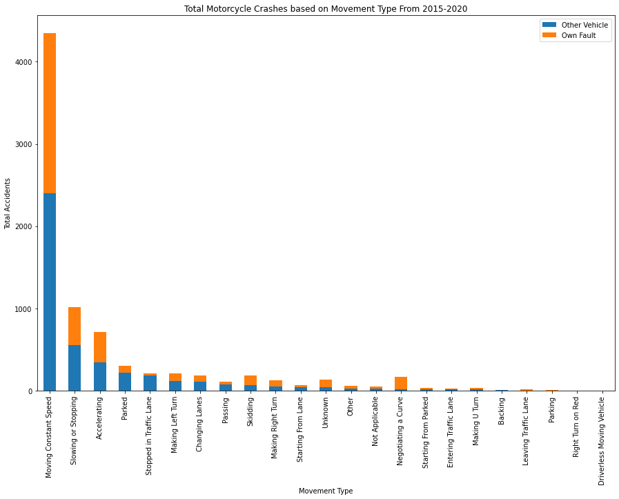

```python
#tallies number of accidents that happend at each type of movement to see what is most frequent
motor_other_vehicle = motorcycles[motorcycles['HARM_EVENT_DESC'] == "Other Vehicle"]
motor_own_fault = motorcycles[motorcycles['HARM_EVENT_DESC'] != "Other Vehicle"]

#create Series of Motorcylists faults and other vehicles faults
movement_t_ov = motor_other_vehicle['MOVEMENT_DESC'].value_counts()
movement_t_of = motor_own_fault['MOVEMENT_DESC'].value_counts()

#Create Conjoin series
movement_types_motor_cat = pd.concat([movement_t_ov,movement_t_of], axis=1)
movement_types_motor_cat.columns = ["Other Vehicle", "Own Fault"]

movement_types_motorcycles_bar = movement_types_motor_cat.plot.bar(xlabel = "Movement Type",
                                                                   ylabel = "Total Accidents",
                                                                   stacked=True,
                                                                   title = "Total Motorcycle Crashes based on Movement Type From 2015-2020")
```

Another thing we can look at is the frequency of different damage levels of vehicles after the crash in motorcycle crashes compared to passenger cars.

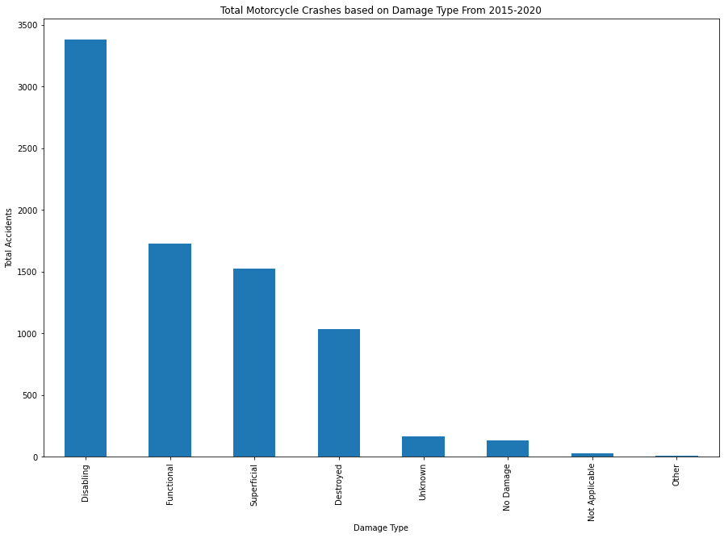

```python
motorcycle_damage = motorcycles['DAMAGE_DESC'].value_counts()

damage_motor_bar = motorcycle_damage.plot.bar(xlabel = "Damage Type",
    ylabel = "Total Accidents",
    stacked=True,
    title = "Total Motorcycle Crashes based on Damage Type From 2015-2020")
```

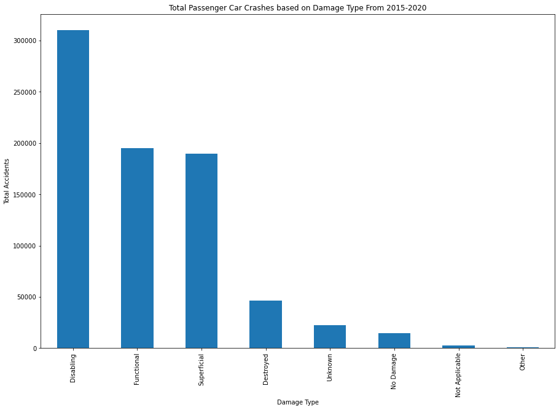

```python
car_damage = cars['DAMAGE_DESC'].value_counts()
damage_car_bar = car_damage.plot.bar(xlabel = "Damage Type",
    ylabel = "Total Accidents",
    stacked=True,
    title = "Total Passenger Car Crashes based on Damage Type From 2015-2020")
```

Another way we can visualize our data is with a heat map. I am using the libarary called seaborn to help create a heatmap to find any correlations between columns in our dataset. Something that I would be interested in looking for here is correlations with BODY_TYPE_CODE which tells us what type of vehicle was reported in the crash.

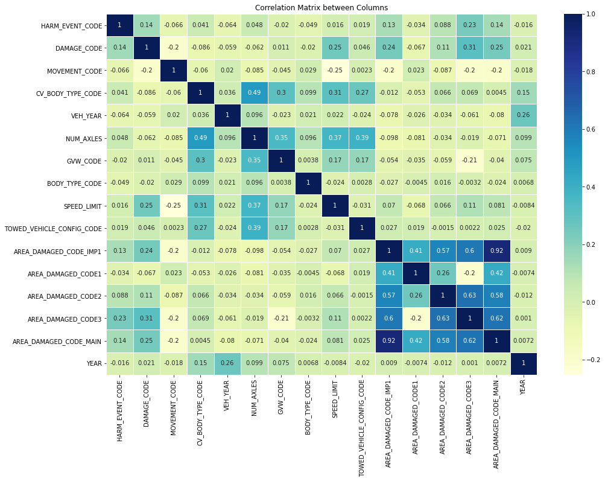

```python
#combining both datasets of motorcycles and cars
df = pd.concat([data[data["BODY_TYPE_DESC"] == "Motorcycle"], data[data["BODY_TYPE_DESC"] == "Passenger Car"]])
df =df[df["HARM_EVENT_DESC"] != "Off Road"]

plt.subplots(figsize = (16,11))
g = sns.heatmap(df.corr("spearman"), annot = True, cmap = "YlGnBu", linewidths=.5)
g.set_title("Correlation Matrix between Columns")
```

## Machine Learning

From here, our next step is to implement some machine learning to be able to find stronger correlations between this data and see if a linear regression model fits the data. This would help us find what the differences are in car crashes as oppose to motorcycle crashes, and how likely someone is to get in a severe crash.

Next we have to create the x and y values to train the dataset before building a linear regression model.

```python
#remove non numerical columns
new_df = df[['HARM_EVENT_CODE', 'DAMAGE_CODE', 'MOVEMENT_CODE', 'BODY_TYPE_CODE', 'SPEED_LIMIT', 'YEAR']]

#columns I will be focusing on
columns = ['HARM_EVENT_CODE', 'DAMAGE_CODE', 'MOVEMENT_CODE', 'SPEED_LIMIT', 'BODY_TYPE_CODE', 'YEAR']


rc = RobustScaler()
new_df[columns] = rc.fit_transform(new_df[columns])

y = new_df['DAMAGE_CODE']
x = new_df.drop('DAMAGE_CODE', axis = 1)
```

```python
x_train, x_test, y_train, y_test = train_test_split(x,y, test_size = .2, random_state = 12)
print(x_train.shape, x_test.shape)
```

```
(632276, 5) (158070, 5)
```

Create Linear Regression Model:

```python
model = linear_model.LinearRegression()
model.fit(x_train, y_train)

co = model.coef_
inter = model.intercept_

y_test_pred = model.predict(x_test)
y_train_pred = model.predict(x_train)

accuracy_train = model.score(x_train, y_train)
accuracy_test = model.score(x_test, y_test)

print(f"Coefficient: {co}")
print(f"Interception: {inter}")
print(f"Y Test Prediction: {y_test_pred}")
print(f"Y Train Prediction: {y_train_pred}")
print(f"Accuracy Train: {accuracy_train}")
print(f"Accuracy Test: {accuracy_test}")
```

```
Coefficient: [ 0.09642495  0.78203667  0.64195041 -0.58579407 -0.12373655]
Interception: 1.0919233306690932
Y Test Prediction: [0.2498523  0.8124556  0.38239271 ... 0.77168888 2.04825055 2.03431663]
Y Train Prediction: [0.29109781 2.07556215 0.98209489 ... 0.41483436 0.54274933 2.15782967]
Accuracy Train: 0.03514932190572895
Accuracy Test: 0.03685855514821501
```

## Visual Representation of Model

Residuals:

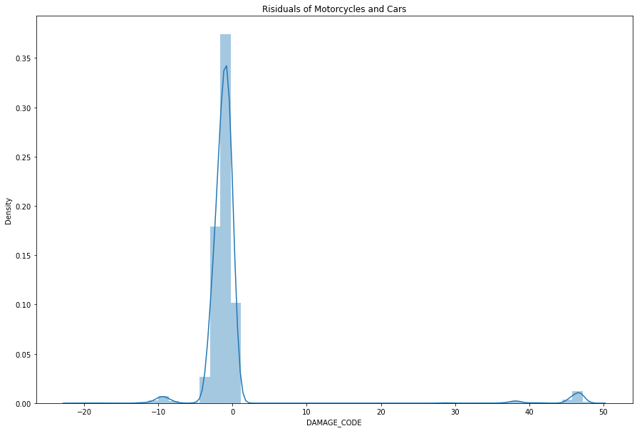

```python
y_pred = model.predict(x_train)
sns.distplot(y_train - y_pred)
plt.title("Risiduals of Motorcycles and Cars")
```

I will also like to seperate the passenger cars and motorcycle crashes to create two seperate models. I belive seeing the two models as well as a visual graph could help us see more differences between motorcycle and car crashes.

```python
motorcycles2 = data[data["BODY_TYPE_DESC"] == "Motorcycle"][['HARM_EVENT_CODE',
                                              'DAMAGE_CODE', 'MOVEMENT_CODE', 'BODY_TYPE_CODE', 'SPEED_LIMIT', 'YEAR']]

cars2 = data[data["BODY_TYPE_DESC"] == "Passenger Car"][['HARM_EVENT_CODE',
                                              'DAMAGE_CODE', 'MOVEMENT_CODE', 'BODY_TYPE_CODE', 'SPEED_LIMIT', 'YEAR']]
```

Car:

```
(631629, 5) (157908, 5)
Coefficient: [ 0.09642495  0.78203667  0.64195041 -0.58579407 -0.12373655]
Interception: 1.0919233306690932
Y Test Prediction: [1.80798136 0.86730601 0.41186468 ... 1.7034487  1.67204609 2.2292709 ]
Y Train Prediction: [ 1.62763041  0.25730502  2.23267814 ...  0.88539502  1.85215841
 10.22951008]
Accuracy Train: 0.0347280994060295
Accuracy Test: 0.03815286594776113
```

[figure not shown]

```python
car_rc = RobustScaler()
cars2[columns] = rc.fit_transform(cars2[columns])

y = cars2['DAMAGE_CODE']
x = cars2.drop('DAMAGE_CODE', axis = 1)

x_train, x_test, y_train, y_test = train_test_split(x,y, test_size = .2, random_state = 12)
print(x_train.shape, x_test.shape)

car_model = linear_model.LinearRegression()
car_model.fit(x_train, y_train)

car_co = car_model.coef_
car_inter = car_model.intercept_

y_test_pred = car_model.predict(x_test)
y_train_pred = car_model.predict(x_train)

accuracy_train = car_model.score(x_train, y_train)
accuracy_test = car_model.score(x_test, y_test)

print(f"Coefficient: {co}")
print(f"Interception: {inter}")
print(f"Y Test Prediction: {y_test_pred}")
print(f"Y Train Prediction: {y_train_pred}")
print(f"Accuracy Train: {accuracy_train}")
print(f"Accuracy Test: {accuracy_test}")

y_pred = car_model.predict(x_train)
sns.distplot(y_train - y_pred)
plt.title("Risiduals of Motorcycles")
```

Motorcycle:

```
(6696, 5) (1674, 5)
Coefficient: [ 6.38131426e-02  1.86039563e-01  1.33226763e-15 -1.23568268e+00
 -9.44501427e-01]
Interception: 1.2571560670870456
Y Test Prediction: [-0.24137356  0.89442589  0.9482354  ...  3.43142703  1.31711957
  2.2659578 ]
Y Train Prediction: [ 0.10858003 -0.60819423  2.19574435 ...  0.94232226  1.85581266
  2.46155035]
Accuracy Train: 0.016493287173030224
Accuracy Test: 0.017007124381291816
```

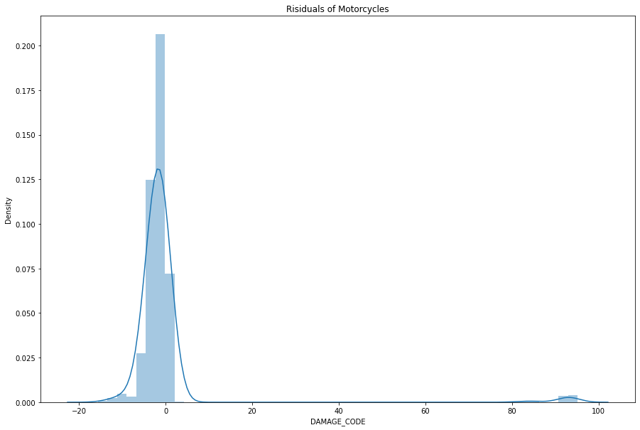

```python
rc = RobustScaler()
motorcycles2[columns] = rc.fit_transform(motorcycles2[columns])

y = motorcycles2['DAMAGE_CODE']
x = motorcycles2.drop('DAMAGE_CODE', axis = 1)

x_train, x_test, y_train, y_test = train_test_split(x,y, test_size = .2, random_state = 12)
print(x_train.shape, x_test.shape)

motor_model = linear_model.LinearRegression()
motor_model.fit(x_train, y_train)

co = motor_model.coef_
inter = motor_model.intercept_

y_test_pred = motor_model.predict(x_test)
y_train_pred = motor_model.predict(x_train)

accuracy_train = motor_model.score(x_train, y_train)
accuracy_test = motor_model.score(x_test, y_test)

print(f"Coefficient: {co}")
print(f"Interception: {inter}")
print(f"Y Test Prediction: {y_test_pred}")
print(f"Y Train Prediction: {y_train_pred}")
print(f"Accuracy Train: {accuracy_train}")
print(f"Accuracy Test: {accuracy_test}")

y_pred = motor_model.predict(x_train)
sns.distplot(y_train - y_pred)
plt.title("Risiduals of Motorcycles")
```

## Conclusion

In this tutorial we went over:

```
-How to read data from a government open source database

-How to organize, manipulate columns, and visualize the data

-How to create linear regression model and train it
```

Webpages I used for this tutorials:

```
Pandas Documentation:
https://pandas.pydata.org/pandas-docs/stable/index.html

Sklearn Linear Regression Documentation:
https://scikit-learn.org/stable/modules/generated/sklearn.linear_model.LinearRegression.html

Maryland Crashes Database:
https://opendata.maryland.gov/Public-Safety/Maryland-Statewide-Vehicle-Crashes-Vehicle-Details/mhft-5t5y
```